# Distribución del pago de los servicios

#### Tabla de contenidos:

1. Notas Preliminares
2. Gases del Caribe
3. Triple A
   1. Datos de la factura
   2. Total pago por habitación
4. Air-e
   1. Tabla de ponderación del consumo
   2. Datos de la factura
   3. Gráfica de los registros de consumo
   4. Datos para tener en cuenta
      1. Diferencias sobre datos de consumo
      2. Valor de corte
      3. Valor del consumo del aire acondicionado
   5. Total a pagar por habitación
5. Movistar
6. Total servicios

## Notas Preliminares

Fabian Ricardo se mudó de la casa el 19 de junio de 2025; por ende, los cálculos de los consumos que le corresponden se calculan hasta esa fecha.

## 1. Gases del Caribe

Datos de la factura del gas:

La factura de la casa grande (contrato No.1020307), por un valor total de $67.895 correspondiente al período 05/2025, está para pagar antes del 17 de junio de 2025.

###### Tabla de contenidos

## 2. Triple A

### 2.1. Datos de la factura

Los siguientes son los datos tomados de la factura de este mes:

La factura del agua (póliza No.121497), por un valor total de $298.608, correspondiente al período: Junio-2025, está para pagar antes del 14 de junio de 2025.

### 2.2. Total pago por habitación

| Habitación | Morador(es) | Ocupación | Total a pagar |
| --- | --- | --- | --- |
| Hab. 1 | Andresito y Kevin | 100.00% | $100.100 |
| Hab. 2 | Jorge | 100.00% | $50.000 |
| Hab. 3 | Gary | 33.33% | $16.700 |
| Hab. 4 | Fabian | 63.33% | $31.700 |
| Apt. | Luis y Andrés | 100.00% | $100.100 |

###### Tabla de contenidos

## 3. Air-e

### 3.1. Tabla de ponderación del consumo:

| Habitación | Morador(es) | Personas | En_casa | Aparatos | Subtotal | Ocupación | Coeficiente |
| --- | --- | --- | --- | --- | --- | --- | --- |
| Hab. 1 | Andresito y Kevin | 2 | 0.5 | 5.0 | 7.5 | 100.00% | 7.500 |
| Hab. 2 | Jorge | 1 | 1.0 | 4.5 | 6.5 | 100.00% | 6.500 |
| Hab. 3 | Gary | 1 | 0.0 | 1.0 | 2.0 | 33.33% | 0.667 |
| Hab. 4 | Fabian | 1 | 0.0 | 1.0 | 2.0 | 63.33% | 1.267 |
| Apt. | Luis y Andrés | 2 | 1.0 | 5.0 | 8.0 | 100.00% | 8.000 |

#### Como leer la tabla de ponderación:

Las columnas **Habitación** y **Morador(es)** son informativas.

La columna **Personas** asigna el valor de 1 a cada individuo residente.

En la columna **En_casa** los valores corresponden a:

- 0.0 -> Trabaja fuera de casa.
- 0.5 -> Trabaja tiempo parcial fuera de casa.
- 1.0 -> Trabaja en casa.

En la columna **Aparatos** los valores se asignan de acuerdo a:

- 0.0 -> No tiene aparatos (o se asignaron a otra persona en la habitación).
- 0.5 -> Tiene aparatos de bajo consumo.
- 1.0 -> Abanico.
- 3.0 -> Aparatos de alto consumo.
- 14.5 -> Aire acondicionado.

La columna **Subtotal** es el resultado de sumar las 3 columnas anteriores.

La columna **Ocupación** es una aproximación porcentual al número de días que la persona ha estado habitando la casa.

La última columna, **Coeficiente** es el resultado de multiplicar las dos columnas anteriores y representa el valor del coeficiente para realizar la ponderación del consumo.

**NOTA:** Por favor reportar cualquier cambio en los patrones de consumo para poder ajustar los cálculos, ya que esto nos afecta a todos.

###### Tabla de contenidos

### 3.2. Datos de la factura:

Para el período 06 - 2025, el valor total a pagar por la factura de energía eléctrica del NIC: 2345873 es de $459.380. Este valor corresponde a un consumo de 495Kws desde el 21 de mayo de 2025 hasta el 18 de junio de 2025 (fecha de la lectura actual), y está para pagar antes del 25 de junio de 2025.

###### Tabla de contenidos

### 3.3. Gráfica de los registros de consumo

La siguiente gráfica muestra los valores diarios de consumo (aproximados) calculados a partir de las lecturas del contador.

**NOTA:** Los valores repetidos se deben a que el consumo no se tomó todos los días, sino solo al inicio y al final del lapso en el que se repiten y se promedió de acuerdo al número de días de ese período.

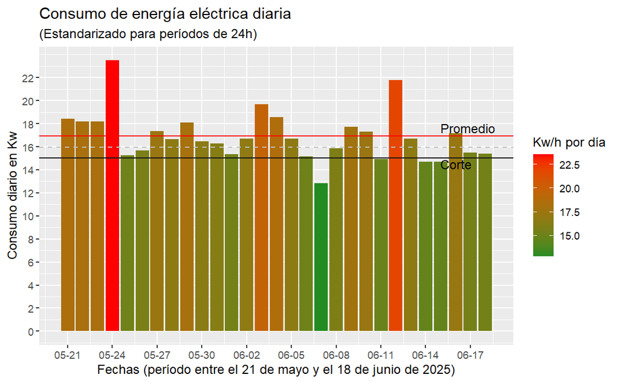

###### Tabla de contenidos

### 3.4. Datos para tener en cuenta

#### 3.4.1. Diferencias sobre datos de consumo

Entre los datos que reporta Air-e en sus lecturas y los recolectados de la información que suministra el contador, aparecen diferencias de consumo. Estas diferencias no deben ser muy altas y se deben principalmente a la hora en que se recolectan los datos. Normalmente las diferencias se compensan en la factura del siguiente período. La siguiente tabla muestra estas diferencias para este mes:

| Factura Air-e | Lectura Contador | Número de días | Diferencia |
| --- | --- | --- | --- |
| 495 Kw | 490.82 Kw | 29 días | 4.18 Kw (a favor de Air-e) |

#### 3.4.2. Valor de corte

El valor de corte se estableció en 15Kw por día (línea horizontal de color negro en la gráfica). Este valor se estableció teniendo en cuenta los cambios en los patrones de consumo y los promedios de meses anteriores, por esto su cercanía al valor promedio del período (línea de color rojo).

Esta línea negra representa un valor de control para observar hacia donde estamos dirigiendo el valor promedio del consumo mensual: si el promedio está por encima estamos aumentando el consumo, si está por debajo lo estamos disminuyendo. Adicionalmente establece una variable de control para ajustar el consumo del aire acondicionado como base en un sistema de promedio movil.

Este mes hemos aumentado el promedio de consumo en 1.925 Kw por día con respecto al corte.

#### 3.4.3. Valor del consumo del aire acondicionado

Los días en que el valor del consumo diario de energía se incrementa notablemente aumentando el promedio mensual (linea de color rojo), se consideran afectados por el uso del aire acondicionado. No se pueden observar los días exactos en que se prendió el aire debido al hecho de no estar tomando los valores del contador todos los días.

Para calcular el valor del consumo del aire se calcula el promedio entre el promedio mensual del consumo (línea roja) y la línea de corte (línea negra), y se suman los valores por encima de este valor (línea gris punteada). De acuerdo a lo anterior, el valor imputado al uso del aire acondicionado se establece a continuación:

| Consumo mes | Valor Factura | Consumo Aire | Costo Aire |
| --- | --- | --- | --- |
| 490.82 Kw | $459.380 | 38.15 Kw | $35.400 |

### 3.5. Total a pagar por habitación

| Habitación | Morador(es) | Total a pagar |
| --- | --- | --- |
| Hab. 1 | Andresito y Kevin | $168.300 |
| Hab. 2 | Jorge | $115.100 |
| Hab. 3 | Gary | $11.800 |
| Hab. 4 | Fabian | $22.400 |
| Apt. | Luis y Andrés | $141.700 |

###### Tabla de contenidos

## 4. Movistar

Los siguientes son los datos de la factura de Movistar por concepto del internet:

El valor total de la factura del Internet por $87.990, con referencia de pago 60512751061, está para pagar antes del 10 de agosto de 2025. Equivalente a $17.600 por persona (5).

###### Tabla de contenidos

## 5. Total Servicios

El total de los servicios por habitación se discrimina a continuación:

| Habitación | TripleA | Air-e | Movistar | Total Servicios |
| --- | --- | --- | --- | --- |
| Hab. 1 | $100.100 | $168.300 | $35.200 | $303.600 |
| Hab. 2 | $50.000 | $115.100 | $17.600 | $182.700 |
| Hab. 3 | $16.700 | $11.800 | $0 | $28.500 |
| Hab. 4 | $31.700 | $22.400 | $0 | $54.100 |
| Apt. | $100.100 | $141.700 | $35.200 | $277.000 |

###### Tabla de contenidos